# Tutoriel Quarto

Guide complet pour la rédaction de rapports scientifiques

# 1 Introduction à Quarto

## 1.1 Qu’est-ce que Quarto ?

**Quarto** est le **successeur moderne de R Markdown**, développé par Posit (anciennement RStudio). C’est un système de publication scientifique et technique open-source.

### 1.1.1 Avantages de Quarto

- ✅ **Multi-langages** : R, Python, Julia, Observable JS
- ✅ **Syntaxe moderne** : Amélioration de R Markdown
- ✅ **Plus de formats** : Sites web, livres, présentations, dashboards
- ✅ **Meilleures performances** : Rendu plus rapide
- ✅ **Écosystème intégré** : Tout-en-un sans packages additionnels
- ✅ **Compatible** : Fonctionne avec RStudio, VS Code, Jupyter

**Compatibilité avec R Markdown**

La plupart des documents R Markdown (.Rmd) fonctionnent directement en Quarto (.qmd) avec peu ou pas de modifications !

## 1.2 Structure d’un document Quarto

Un document Quarto (.qmd) contient :

1. **En-tête YAML** (métadonnées)
2. **Texte en Markdown** (formatage)
3. **Chunks de code** (R, Python, etc.)
4. **Callouts et divs** (blocs spéciaux)

# 2 L’en-tête YAML

L’en-tête YAML est **plus puissant** dans Quarto qu’en R Markdown.

## 2.1 Exemple d’en-tête de base

```yaml
---
title: "Analyse de la croissance de la daurade"
subtitle: "Étude en ferme aquacole méditerranéenne"
author: "Dr. Marie Martin"
date: today
lang: fr
format: html
---
```

## 2.2 Options de format HTML

### 2.2.1 Configuration complète

```yaml
format:
  html:
    # Sommaire
    toc: true
    toc-location: left        # left, right, body
    toc-depth: 3
    toc-title: "Sommaire"
    number-sections: true
    number-depth: 3

    # Code
    code-fold: false          # true, false, show
    code-tools: true          # Bouton pour afficher/masquer le code
    code-link: true           # Liens vers documentation
    code-line-numbers: false

    # Apparence
    theme: cosmo              # Thème Bootstrap
    highlight-style: tango    # Coloration syntaxique
    css: custom.css           # CSS personnalisé

    # Options avancées
    embed-resources: true     # Document autonome
    smooth-scroll: true
    anchor-sections: true
    fig-cap-location: bottom
    tbl-cap-location: top
```

**Thèmes disponibles** : `default`, `cerulean`, `cosmo`, `cyborg`, `darkly`, `flatly`, `journal`, `litera`, `lumen`, `lux`, `materia`, `minty`, `morph`, `pulse`, `quartz`, `sandstone`, `simplex`, `sketchy`, `slate`, `solar`, `spacelab`, `superhero`, `united`, `vapor`, `yeti`, `zephyr`

## 2.3 Options de format PDF

```yaml
format:
  pdf:
    toc: true
    number-sections: true
    colorlinks: true
    geometry:
      - top=30mm
      - left=20mm
    papersize: a4
    fontsize: 11pt
    documentclass: article
    fig-pos: 'H'
    keep-tex: true           # Conserver le fichier .tex
```

## 2.4 Plusieurs formats simultanés

```yaml
format:
  html:
    toc: true
    theme: cosmo
  pdf:
    toc: true
    colorlinks: true
  docx:
    toc: true
```

## 2.5 Paramètres du document

```yaml
params:
  espece: "Sparus aurata"
  temperature_min: 20
  temperature_max: 26
```

Utilisation dans le texte : `Sparus aurata`

# 3 Mise en forme du texte

## 3.1 Titres et sections

Identique à R Markdown :

```markdown
# Titre de niveau 1
## Titre de niveau 2
### Titre de niveau 3
#### Titre de niveau 4
##### Titre de niveau 5
###### Titre de niveau 6
```

### 3.1.1 Exemple en halieutique

# 4 Évaluation des stocks de thon rouge

## 4.1 Matériel et méthodes

### 4.1.1 Zone d’étude

L’étude a été menée en Méditerranée occidentale.

### 4.1.2 Échantillonnage

Les captures ont été effectuées par chalutage pélagique.

## 4.2 Formatage du texte

[output not shown]

### 4.2.1 Exemple pratique

Le *bar européen* (*Dicentrarchus labrax*) est une espèce d’**intérêt commercial majeur** en Méditerranée. *ATTENTION* : Le taux de mortalité peut atteindre 50% si la température dépasse 28°C. La concentration en O<sub>2</sub> doit rester > 5 mg·L<sup>-1</sup>.

## 4.3 Listes

### 4.3.1 Liste à puces

```markdown
Paramètres environnementaux mesurés :

- Température (°C)
- Salinité (PSU)
- Oxygène dissous (mg/L)
  - Matin (6h)
  - Après-midi (14h)
- pH
- Turbidité (NTU)
```

**Rendu** :

Paramètres environnementaux mesurés :

- Température (°C)
- Salinité (PSU)
- Oxygène dissous (mg/L)
  - Matin (6h)
  - Après-midi (14h)
- pH
- Turbidité (NTU)

### 4.3.2 Liste numérotée

```markdown
Protocole de biométrie :

1. Anesthésier le poisson (MS-222, 100 mg/L)
2. Mesurer la longueur totale (LT, ± 1 mm)
3. Peser (± 0.1 g)
4. Photographier pour analyse morphométrique
5. Retour dans le bassin de stabulation
```

**Rendu** :

Protocole de biométrie :

1. Anesthésier le poisson (MS-222, 100 mg/L)
2. Mesurer la longueur totale (LT, ± 1 mm)
3. Peser (± 0.1 g)
4. Photographier pour analyse morphométrique
5. Retour dans le bassin de stabulation

### 4.3.3 Liste de tâches (HTML uniquement)

```markdown
- [x] Calibration de la sonde à oxygène
- [x] Acclimation des poissons
- [ ] Mesures biométriques finales
- [ ] Analyse statistique
```

**Rendu** :

- Calibration de la sonde à oxygène
- Acclimation des poissons
- Mesures biométriques finales
- Analyse statistique

## 4.4 Liens et images

### 4.4.1 Liens

```markdown
Consulter le [portail FishBase](https://www.fishbase.se)

Email : [contact@aquaculture.fr](mailto:contact@aquaculture.fr)
```

**Rendu** :

Consulter le [portail FishBase](https://www.fishbase.se)

### 4.4.2 Images

```markdown
![Daurade royale](image.jpg)

![Daurade royale](image.jpg){width=50%}

![Daurade royale](image.jpg){width=300px fig-align="center"}
```

## 4.5 Tableaux

### 4.5.1 Tableau simple

```markdown
| Espèce | Nom scientifique | Taille max (cm) |
|--------|------------------|-----------------|
| Daurade royale | *Sparus aurata* | 70 |
| Bar européen | *Dicentrarchus labrax* | 100 |
| Loup de l'Atlantique | *Anarhichas lupus* | 150 |
```

**Rendu** :

| Espèce | Nom scientifique | Taille max (cm) |
| --- | --- | --- |
| Daurade royale | *Sparus aurata* | 70 |
| Bar européen | *Dicentrarchus labrax* | 100 |
| Loup de l’Atlantique | *Anarhichas lupus* | 150 |

### 4.5.2 Tableau avec alignement

```markdown
| Paramètre | Valeur optimale | Tolérance |
|:----------|:---------------:|----------:|
| Température | 23-25°C | ± 3°C |
| Oxygène | 6-8 mg/L | > 5 mg/L |
| pH | 7.5-8.5 | ± 0.5 |
```

**Rendu** :

| Paramètre | Valeur optimale | Tolérance |
| --- | --- | --- |
| Température | 23-25°C | ± 3°C |
| Oxygène | 6-8 mg/L | > 5 mg/L |
| pH | 7.5-8.5 | ± 0.5 |

### 4.5.3 Légende de tableau

```markdown
: Paramètres optimaux pour l'élevage de la daurade {#tbl-parametres}

| Paramètre | Valeur |
|-----------|--------|
| ... | ... |
```

Référence : `@tbl-parametres`

# 5 Formules mathématiques

Quarto utilise **LaTeX** pour les mathématiques (identique à R Markdown).

## 5.1 Formules en ligne

```markdown
Le taux de croissance instantanée $G_i$ est donné par : $G_i = \frac{dW}{dt} \times \frac{1}{W}$
```

**Rendu** :

Le taux de croissance instantanée $G_i$ est donné par : $G_i = \frac{dW}{dt} \times \frac{1}{W}$

## 5.2 Formules centrées

```markdown
$$
TCA = \frac{W_f - W_i}{t}
$$
```

**Rendu** :

$$TCA = \frac{W_f - W_i}{t}$$

## 5.3 Formules en aquaculture/halieutique

### 5.3.1 Taux de croissance pondéral (TCA)

$$TCA = \frac{W_f - W_i}{t}$$

où $W_f$ = poids final (g), $W_i$ = poids initial (g), $t$ = durée (jours)

### 5.3.2 Taux de croissance spécifique (SGR)

$$SGR = \frac{\ln(W_f) - \ln(W_i)}{t} \times 100$$

### 5.3.3 Facteur de condition de Fulton

$$K = \frac{W}{L^3} \times 100$$

où $W$ = poids (g), $L$ = longueur totale (cm)

### 5.3.4 Indice de conversion alimentaire (IC ou FCR)

$$IC = \frac{\text{Quantité d'aliment distribuée (kg)}}{\text{Gain de poids vif (kg)}}$$

### 5.3.5 Coefficient thermique de croissance (TGC)

$$TGC = \frac{W_f^{1/3} - W_i^{1/3}}{T \times t} \times 1000$$

où $T$ = température moyenne (°C), $t$ = durée (jours)

### 5.3.6 Modèle de croissance de von Bertalanffy

$$L_t = L_\infty \left[1 - e^{-K(t - t_0)}\right]$$

**Paramètres** :

- $L_t$ : longueur à l’âge $t$
- $L_\infty$ : longueur asymptotique (cm)
- $K$ : coefficient de croissance (an<sup>-1</sup>)
- $t_0$ : âge théorique à longueur nulle (an)

### 5.3.7 Mortalité totale (Z)

$$Z = M + F$$

où :

- $Z$ = mortalité totale (an<sup>-1</sup>)
- $M$ = mortalité naturelle (an<sup>-1</sup>)
- $F$ = mortalité par pêche (an<sup>-1</sup>)

### 5.3.8 Modèle de Beverton-Holt (recrutement)

$$R = \frac{\alpha S}{1 + \beta S}$$

où $R$ = recrutement, $S$ = stock reproducteur

### 5.3.9 Rendement par recrue (Y/R)

$$\frac{Y}{R} = F \times W_\infty \times \sum_{t=t_r}^{\infty} e^{-Z(t-t_r)}$$

## 5.4 Équations numérotées

```markdown
$$
\text{Biomasse} = N \times \bar{W}
$$ {#eq-biomasse}

Selon l'équation @eq-biomasse, la biomasse totale dépend de l'effectif.
```

**Rendu** :

$$\text{Biomasse} = N \times \bar{W}
\tag{1}$$

Selon l’équation Équation 1, la biomasse totale dépend de l’effectif.

## 5.5 Symboles spéciaux

| Symbole | Code LaTeX | Utilisation aquaculture |
| --- | --- | --- |
| $\alpha$ | `\alpha` | Niveau de confiance |
| $\beta$ | `\beta` | Paramètre de régression |
| $\mu$ | `\mu` | Moyenne |
| $\sigma$ | `\sigma` | Écart-type |
| $\Delta$ | `\Delta` | Variation |
| $\sum$ | `\sum` | Somme |
| $\prod$ | `\prod` | Produit |
| $\int$ | `\int` | Intégrale |
| $\infty$ | `\infty` | Infini ($L_\infty$) |
| $\pm$ | `\pm` | Plus ou moins |
| $\approx$ | `\approx` | Approximativement |
| $\propto$ | `\propto` | Proportionnel à |
| $\geq$ | `\geq` | Supérieur ou égal |
| $\leq$ | `\leq` | Inférieur ou égal |

# 6 Chunks de code

## 6.1 Structure d’un chunk

Identique à R Markdown :

````markdown
```{.r}
# Code R ici
```
````

## 6.2 Nommage des chunks

````markdown
```{.r calcul-biomasse}
biomasse <- 1500 * 45.2
biomasse
```
````

## 6.3 Options des chunks

### 6.3.1 Options principales

| Option | Valeurs | Description |
| --- | --- | --- |
| `echo` | `true`/`false` | Afficher le code |
| `eval` | `true`/`false` | Exécuter le code |
| `include` | `true`/`false` | Inclure le chunk |
| `output` | `true`/`false`/`asis` | Format de sortie |
| `warning` | `true`/`false` | Afficher warnings |
| `message` | `true`/`false` | Afficher messages |
| `error` | `true`/`false` | Afficher erreurs |
| `fig-width` | nombre | Largeur figure (pouces) |
| `fig-height` | nombre | Hauteur figure |
| `fig-cap` | texte | Légende |
| `fig-align` | `left`, `center`, `right` | Alignement |
| `label` | texte | Étiquette pour référence |

**Différence avec R Markdown**

Dans Quarto, les options utilisent des **tirets** (`fig-width`) au lieu de points (`fig.width`). Les deux syntaxes fonctionnent mais les tirets sont recommandés.

### 6.3.2 Syntaxe Quarto (recommandée)

````markdown
```{.r}
#| label: fig-croissance
#| echo: false
#| fig-cap: "Évolution du poids moyen"
#| fig-width: 8
#| fig-height: 6

plot(temps, poids)
```
````

### 6.3.3 Syntaxe R Markdown (compatible)

````markdown
```{.r fig-croissance, echo=FALSE, fig.cap="Évolution du poids moyen", fig.width=8}
plot(temps, poids)
```
````

## 6.4 Exemples pratiques

### 6.4.1 Chunk setup

````markdown
```{.r}
#| label: setup
#| include: false

library(ggplot2)
library(dplyr)
library(knitr)

# Options globales
knitr::opts_chunk$set(
  echo = TRUE,
  warning = FALSE,
  message = FALSE
)
```
````

### 6.4.2 Afficher uniquement le résultat

````markdown
```{.r}
#| echo: false

biomasse_totale <- 2500 * 52.8
cat("Biomasse totale :", round(biomasse_totale/1000, 1), "kg")
```
````

**Rendu** :

```
Biomasse totale : 132 kg
```

### 6.4.3 Code non exécuté (exemple)

````markdown
```{.r}
#| eval: false

# Exemple de calcul du SGR (non exécuté)
SGR <- (log(poids_final) - log(poids_initial)) / duree * 100
```
````

**Rendu** :

```r
# Exemple de calcul du SGR
SGR <- (log(poids_final) - log(poids_initial)) / duree * 100
```

### 6.4.4 Figure avec référence croisée

````markdown
```{.r}
#| label: fig-temperature
#| fig-cap: "Évolution de la température de l'eau"
#| fig-width: 8
#| fig-height: 5

jours <- 1:30
temperature <- 22 + 2 * sin(jours / 5) + rnorm(30, sd = 0.5)

plot(jours, temperature, type = "l", col = "red", lwd = 2,
     xlab = "Jour", ylab = "Température (°C)",
     main = "Suivi thermique du bassin")
abline(h = 23, col = "blue", lty = 2)
```
````

Référence dans le texte : `@fig-temperature`

**Rendu** :

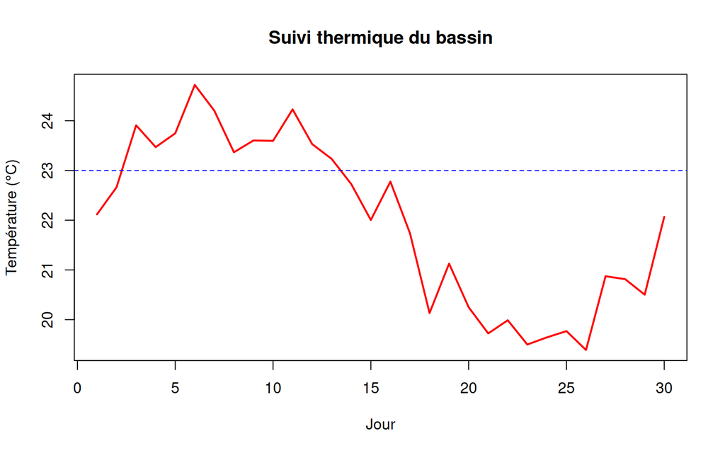

Figure 1: Évolution de la température de l’eau

La Figure 1 montre les variations journalières de température.

## 6.5 Code en ligne

```markdown
La température moyenne était de 22°C.
```

# 7 Callouts (Blocs spéciaux)

Les **callouts** sont une fonctionnalité unique à Quarto pour mettre en évidence des informations.

## 7.1 Types de callouts

### 7.1.1 Note

```markdown
:::{.callout-note}
La daurade royale (*Sparus aurata*) est une espèce hermaphrodite protandre.
:::
```

**Rendu** :

**Note**

La daurade royale (*Sparus aurata*) est une espèce hermaphrodite protandre.

### 7.1.2 Astuce

```markdown
:::{.callout-tip}
## Conseil pratique

Pour mesurer précisément les poissons, utilisez un ichtyomètre calibré.
:::
```

**Rendu** :

**Conseil pratique**

Pour mesurer précisément les poissons, utilisez un ichtyomètre calibré.

### 7.1.3 Avertissement

```markdown
:::{.callout-warning}
Température > 28°C : risque de stress thermique et mortalité !
:::
```

**Rendu** :

**Avertissement**

Température > 28°C : risque de stress thermique et mortalité !

### 7.1.4 Important

```markdown
:::{.callout-important}
L'oxygène dissous doit **impérativement** rester supérieur à 5 mg/L.
:::
```

**Rendu** :

**Important**

L’oxygène dissous doit **impérativement** rester supérieur à 5 mg/L.

### 7.1.5 Attention

```markdown
:::{.callout-caution}
## Manipulation des poissons

Ne jamais manipuler les poissons à mains nues. Utiliser des gants humides.
:::
```

**Rendu** :

**Manipulation des poissons**

Ne jamais manipuler les poissons à mains nues. Utiliser des gants humides.

## 7.2 Callouts pliables

```markdown
:::{.callout-note collapse="true"}
## Détails du protocole

1. Acclimation : 7 jours
2. Mesures : tous les 15 jours
3. Alimentation : 2% biomasse/jour
:::
```

**Rendu** :

**Détails du protocole**

1. Acclimation : 7 jours
2. Mesures : tous les 15 jours
3. Alimentation : 2% biomasse/jour

## 7.3 Callouts avec icônes personnalisées

```markdown
:::{.callout-tip icon=false}
## 🐟 Astuce aquaculture

Maintenir un ratio mâles/femelles de 1:3 pour optimiser la reproduction.
:::
```

# 8 Exemple complet : Analyse de stock

## 8.1 Introduction

Cette étude porte sur l’évaluation du stock de **bar européen** (*Dicentrarchus labrax*) en Méditerranée occidentale sur la période 2018-2022.

**Objectifs**

1. Analyser l’évolution des captures
2. Estimer les paramètres de croissance
3. Évaluer l’état du stock

## 8.2 Données de captures

### 8.2.1 Statistiques descriptives

```r
library(dplyr)
library(knitr)

stats <- donnees_captures %>%
  group_by(annee) %>%
  summarise(
    `Captures moyennes (t)` = round(mean(captures_tonnes), 1),
    `Écart-type (t)` = round(sd(captures_tonnes), 1),
    `Min (t)` = min(captures_tonnes),
    `Max (t)` = max(captures_tonnes)
  )

kable(stats, caption = "Statistiques annuelles des captures de bar")
```

Statistiques annuelles des captures de bar

| annee | Captures moyennes (t) | Écart-type (t) | Min (t) | Max (t) |
| --- | --- | --- | --- | --- |
| 2018 | 160.9 | 35.1 | 108 | 227 |
| 2019 | 153.4 | 42.3 | 79 | 214 |
| 2020 | 150.6 | 29.3 | 70 | 199 |
| 2021 | 155.8 | 27.0 | 92 | 195 |
| 2022 | 146.5 | 36.1 | 92 | 210 |

### 8.2.2 Évolution temporelle

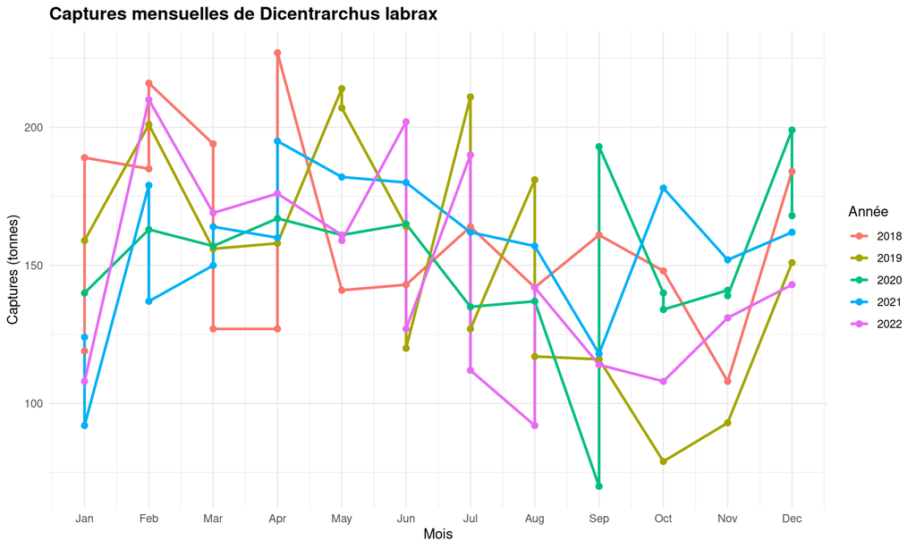

Figure 2: Évolution des captures mensuelles de bar européen (2018-2022)

```r
library(ggplot2)

ggplot(donnees_captures, aes(x = mois, y = captures_tonnes, color = factor(annee))) +
  geom_line(size = 1) +
  geom_point(size = 2) +
  scale_x_continuous(breaks = 1:12, labels = month.abb) +
  labs(
    title = "Captures mensuelles de Dicentrarchus labrax",
    x = "Mois",
    y = "Captures (tonnes)",
    color = "Année"
  ) +
  theme_minimal() +
  theme(
    plot.title = element_text(face = "bold", size = 14),
    legend.position = "right"
  )
```

## 8.3 Paramètres biologiques

### 8.3.1 Relation taille-poids

La relation taille-poids suit le modèle allométrique :

$$W = a \times L^b
\tag{2}$$

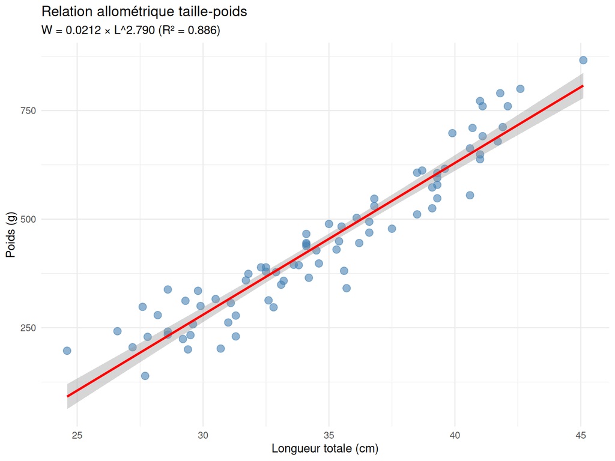

Figure 3: Relation taille-poids du bar européen

```r
# Régression log-log
modele <- lm(log(poids_g) ~ log(longueur_cm), data = donnees_bio)

# Paramètres
a <- exp(coef(modele)[1])
b <- coef(modele)[2]

ggplot(donnees_bio, aes(x = longueur_cm, y = poids_g)) +
  geom_point(alpha = 0.6, size = 3, color = "steelblue") +
  geom_smooth(method = "lm", formula = y ~ x,
              se = TRUE, color = "red") +
  labs(
    title = "Relation allométrique taille-poids",
    subtitle = sprintf("W = %.4f × L^%.3f (R² = %.3f)",
                      a, b, summary(modele)$r.squared),
    x = "Longueur totale (cm)",
    y = "Poids (g)"
  ) +
  theme_minimal()
```

**Résultats** :

- Coefficient $a$ = 0.0212
- Exposant $b$ = 2.79
- R² = 0.886

## 8.4 Conclusions

**Recommandations de gestion**

1. Maintenir l’effort de pêche stable
2. Respecter la taille minimale de capture (42 cm)
3. Instaurer une fermeture saisonnière (juin-juillet)
4. Surveiller le recrutement annuel

# 9 Mise en page avancée

## 9.1 Colonnes

### 9.1.1 Deux colonnes

```markdown
:::{.columns}

:::{.column width="50%"}
**Avantages de l'aquaculture** :

- Production contrôlée
- Qualité constante
- Traçabilité
:::

:::{.column width="50%"}
**Défis** :

- Investissement initial
- Gestion sanitaire
- Impact environnemental
:::

:::
```

**Rendu** :

**Avantages de l’aquaculture** :

- Production contrôlée
- Qualité constante
- Traçabilité

**Défis** :

- Investissement initial
- Gestion sanitaire
- Impact environnemental

## 9.2 Onglets (HTML uniquement)

```markdown
::: {.panel-tabset}

## Daurade

*Sparus aurata* - Température optimale : 23-25°C

## Bar

*Dicentrarchus labrax* - Température optimale : 20-24°C

## Loup

*Anarhichas lupus* - Température optimale : 8-12°C

:::
```

**Rendu** :

**Daurade**

*Sparus aurata* - Température optimale : 23-25°C

**Bar**

*Dicentrarchus labrax* - Température optimale : 20-24°C

**Loup**

*Anarhichas lupus* - Température optimale : 8-12°C

## 9.3 Marges et aside

```markdown
::: {.aside}
**Note** : Les données proviennent de la FAO
:::
```

# 10 Références croisées

## 10.1 Figures

```markdown
Voir la @fig-temperature pour les détails.
```

## 10.2 Tableaux

```markdown
: Paramètres de croissance {#tbl-croissance}

Le @tbl-croissance résume les résultats.
```

## 10.3 Équations

```markdown
L'équation @eq-biomasse montre la relation.
```

## 10.4 Sections

```markdown
Voir la @sec-equations pour plus d'informations.
```

# 11 Rendu du document

## 11.1 Depuis RStudio

1. Cliquer sur **Render** (ou Ctrl+Shift+K)
2. Le document s’ouvre automatiquement

## 11.2 Depuis le terminal

```bash
# HTML
quarto render document.qmd

# PDF
quarto render document.qmd --to pdf

# Word
quarto render document.qmd --to docx

# Tous les formats
quarto render document.qmd --to all
```

## 11.3 Prévisualisation en direct

```bash
quarto preview document.qmd
```

Un serveur local s’ouvre et le document se met à jour automatiquement à chaque modification.

# 12 Différences clés R Markdown vs Quarto

| Aspect | R Markdown | Quarto |
| --- | --- | --- |
| **Extension** | `.Rmd` | `.qmd` |
| **Rendu** | `Knit` | `Render` |
| **Options chunks** | `fig.width=8` | `fig-width: 8` |
| **Callouts** | Packages tiers | Natif |
| **Langages** | Principalement R | R, Python, Julia, Observable |
| **Références croisées** | `bookdown` requis | Natif |
| **Thèmes** | limités | Plus nombreux |
| **CLI** | Non | Oui (`quarto` commande) |

# 13 Astuces avancées

## 13.1 Paramètres dynamiques

```yaml
params:
  espece: "Sparus aurata"
  n_echantillons: 100
```

Utilisation :

```markdown
L'espèce étudiée est Sparus aurata avec n = 100.
```

## 13.2 Inclusion conditionnelle

```r
# Ce code s'exécute uniquement si mode = "detaille"
```

## 13.3 Code Python (si installé)

````markdown
```{.python}
import pandas as pd
import numpy as np

data = pd.DataFrame({
  'longueur': np.random.normal(35, 5, 100),
  'poids': np.random.normal(500, 100, 100)
})

print(data.describe())
```
````

# 14 Ressources complémentaires

## 14.1 Documentation

- [Site officiel Quarto](https://quarto.org)
- [Guide Quarto](https://quarto.org/docs/guide/)
- [Galerie d’exemples](https://quarto.org/docs/gallery/)

## 14.2 Comparaison R Markdown

- [FAQ R Markdown → Quarto](https://quarto.org/docs/faq/rmarkdown.html)